# Final Project: Statistical Analysis by State of How Nicaraguan Asylum claims vary by Key Factors

2023-12-13

I. Introduction and Nicaraguan Asylum Filings and Decisions Trends over the last 23 years

For this project, I have chosen to investigate the immigration patterns of Nicaraguans in the United States. The rationale behind my choice lies in the substantial increase in immigration from Latin America to the US over the past decade. Specifically, I have focused on Nicaragua due to the socio-political crisis triggered by protests against Daniel Ortega’s authoritarian regime in 2018, which led to a significant rise in immigration to the US, with many seeking asylum.

As part of my analysis, I will initially examine the trends in asylum applications filed in each US state, along with the corresponding approval and denial rates. However, it’s important to note that this data only reflects the relationship between asylum filings and decisions, providing a limited view of the overall immigration trend. To gain a more comprehensive understanding of why immigrants choose to settle in particular states, given their background as political asylum seekers fleeing a left-wing oppressive government and the current socio-economic and political conditions offered by each state, it is essential to incorporate additional variables into the analysis.

I hypothesize that factors such as the political affiliation of the state’s governor, the percentage of Hispanic populations, and the state’s GDP per capita have a significant influence on the trends in asylum applications and decisions among Nicaraguan migrants in the United States post-2018. Specifically, states with a higher proportion of Hispanic populations, governed by parties more supportive of immigration, and with a higher GDP per capita, may experience higher rates of asylum applications and approvals for Nicaraguan migrants.

This study is of particular interest as immigration rates have been on the rise in recent years, and it can provide valuable insights into immigration trends and the decision-making processes of immigrants, taking into account their backgrounds and the conditions offered by each state. This analysis may also contribute to predicting the future implications of these new populations settling in various states.

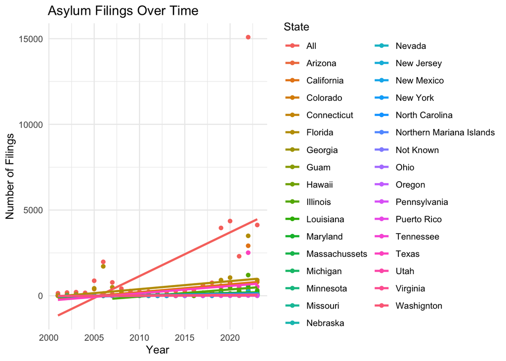

```r
# Graph 1- asylum filings

library(ggplot2)
library(tidyr)

# Loading the data
filings <- read.csv("asylum_filings.csv")



# Converting all year columns to numeric values
year_cols <- grep("^X[0-9]{4}$", names(filings))
filings[, year_cols] <- lapply(filings[, year_cols], function(x) as.numeric(gsub("[^0-9.]", "", x)))

# Reshaping the data to a longer format
asylum_long <- tidyr::pivot_longer(filings,
                                   cols = starts_with("X"),
                                   names_to = "Year",
                                   values_to = "Filings")

# Convert the Year from 'XYYYY' to 'YYYY' format
asylum_long$Year <- as.numeric(sub("X", "", asylum_long$Year))

# Plot
ggplot(asylum_long, aes(x = Year, y = Filings, color = State)) +
  geom_point() +
  geom_smooth(method = "lm", se = FALSE) +
  theme_minimal() +
  labs(title = "Asylum Filings Over Time",
       x = "Year",
       y = "Number of Filings")
```

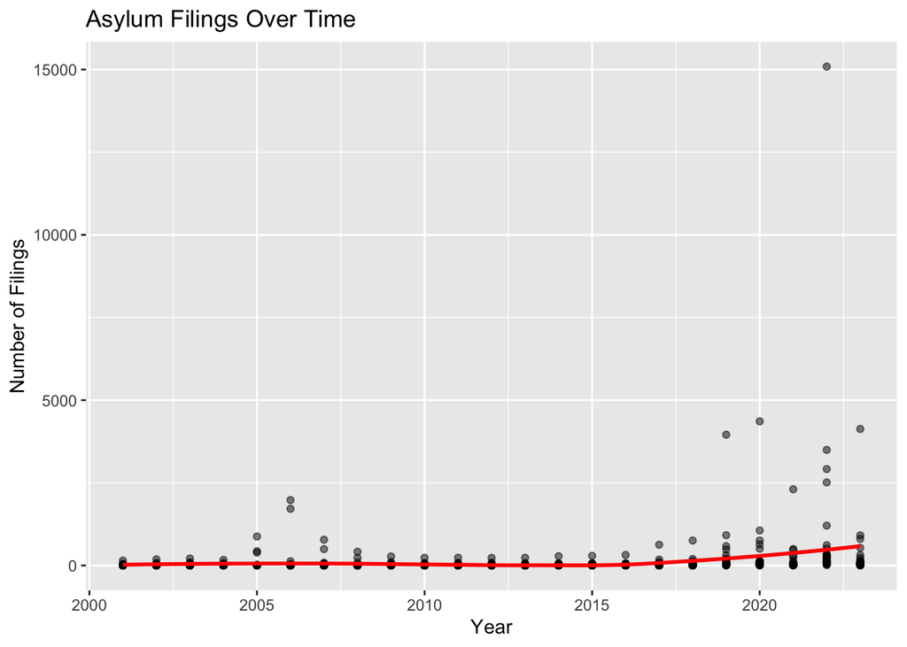

```r
#graph 2 - asylum filings without the labels
filings <- read.csv("asylum_filings.csv")



# Converting all years to numeric values
year_cols <- grep("^X[0-9]{4}$", names(filings))
filings[, year_cols] <- lapply(filings[, year_cols], function(x) as.numeric(gsub("[^0-9.]", "", x)))

# Reshaping the data to a longer format
asylum_long <- tidyr::pivot_longer(filings,
                                   cols = starts_with("X"),
                                   names_to = "Year",
                                   values_to = "Filings")

# Converting the Year from 'XYYYY' to 'YYYY' format
asylum_long$Year <- as.numeric(sub("X", "", asylum_long$Year))


# visualization
ggplot(asylum_long, aes(x = Year, y = Filings)) +
  geom_point(alpha = 0.5, color = "black") +
  geom_smooth(method = "loess", se = FALSE, color = "red") +
  labs(title = "Asylum Filings Over Time",
       x = "Year",
       y = "Number of Filings") +
  theme(legend.position = "none")
```

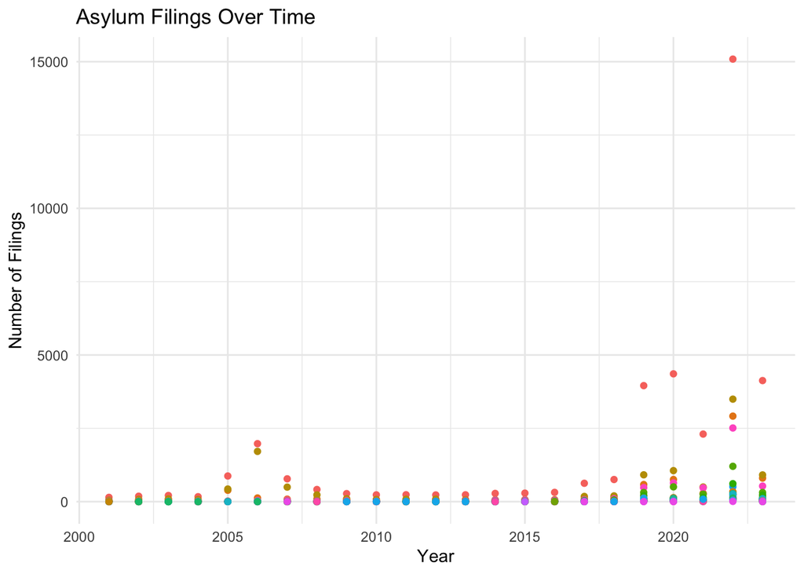

```r
# graph 3- colored asylum filings over the years
library(ggplot2)
library(tidyr)

# Reshaping the data to a longer format
asylum_long <- tidyr::pivot_longer(filings,
                                   cols = starts_with("X"),
                                   names_to = "Year",
                                   values_to = "Filings")

# Converting the Year from 'XYYYY' to 'YYYY' format
asylum_long$Year <- as.numeric(sub("X", "", asylum_long$Year))

#visualization
ggplot(asylum_long, aes(x = Year, y = Filings, color = State)) +
  geom_point() +
  theme_minimal() +
  labs(title = "Asylum Filings Over Time",
       x = "Year",
       y = "Number of Filings") +
  theme(legend.position = "none")
```

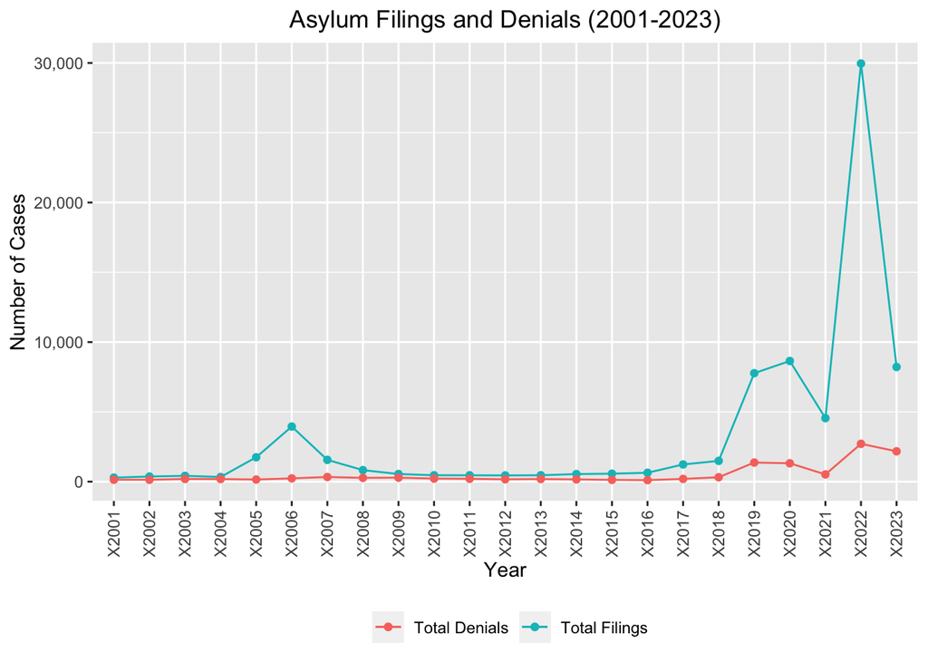

```r
#loading libraries
library(ggplot2)
library(dplyr)
library(ggplot2)
library(dplyr)
library(tidyr)

#loading files

filings <- read.csv("asylum_filings.csv")


decisions_denied <- read.csv("decisions_denied.csv")


library(ggplot2)
library(dplyr)
library(tidyr)

library(tidyverse)
# Data cleaning and preparation/ adjusting column selection as per your dataset's structure/ excluding columns that are not needed
filings_cleaned <- filings |>
    select(-State, -matches("All|Never|Detained|Released")) |>
    gather(key = "Year", value = "Filings") |>
    group_by(Year) |>
    summarize(TotalFilings = sum(as.numeric(gsub(",", "", Filings)), na.rm = TRUE))
denials_cleaned <- decisions_denied |>
    select(-State) |>
    gather(key = "Year", value = "Denials") |>
    group_by(Year) |>
    summarize(TotalDenials = sum(as.numeric(gsub(",", "", Denials)), na.rm = TRUE))

# Merging data
merged_data <- merge(filings_cleaned, denials_cleaned, by = "Year")



#visualizations
ggplot(merged_data, aes(x = Year)) +
    geom_line(aes(y = TotalFilings, group = 1, color = "Total Filings")) +
    geom_line(aes(y = TotalDenials, group = 1, color = "Total Denials")) +
  geom_point(aes(y = TotalFilings, group = 1, color = "Total Filings")) +
    geom_point(aes(y = TotalDenials, group = 1, color = "Total Denials")) +
    scale_x_discrete(breaks = merged_data$Year) +
    scale_y_continuous(labels = scales::comma) +
    labs(title = "Asylum Filings and Denials (2001-2023)",
         x = "Year",
         y = "Number of Cases",
         color = "Legend") +
   theme(axis.text.x = element_text(angle = 90, vjust = 0.5, hjust=1),
          legend.title = element_blank(),
          plot.title = element_text(hjust = 0.5),
          legend.position = "bottom")
```

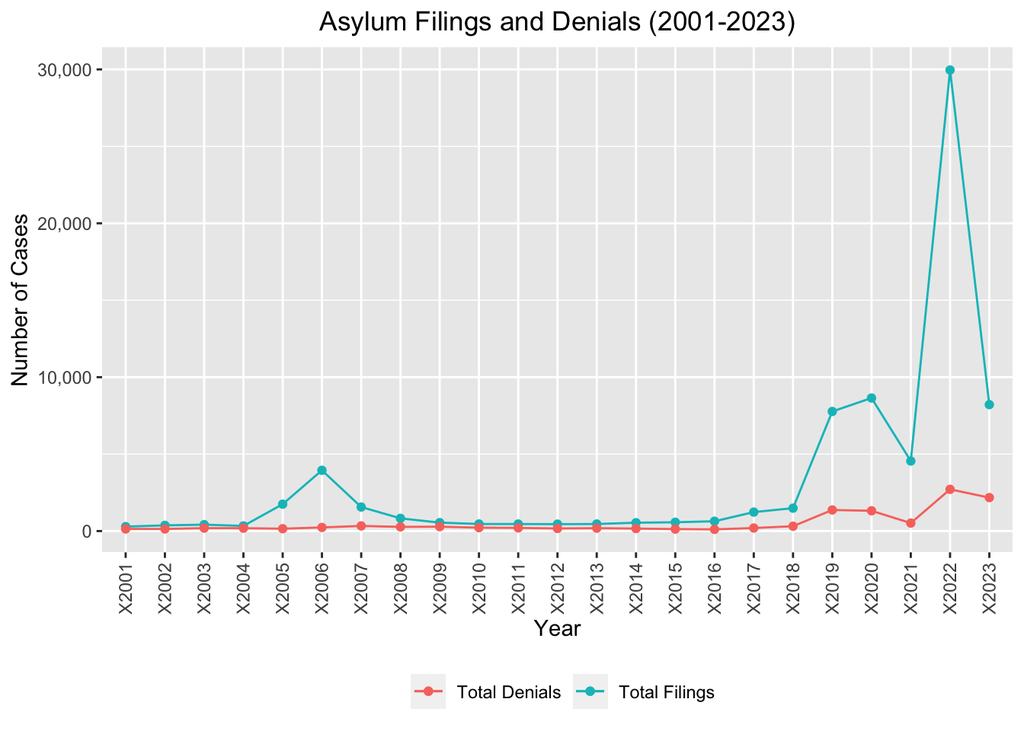

```r
#Part 1.3 Asylum filings and denials
##loading libraries
library(ggplot2)
library(dplyr)

library(ggplot2)
library(dplyr)
library(tidyr)

#loading data
filings <- read.csv("asylum_filings.csv")


decisions_denied <- read.csv("decisions_denied.csv")

library(ggplot2)
library(dplyr)
library(tidyr)

library(tidyverse)

# Data cleaning and preparation/ adjusting column selection as per your dataset's structure/ excluding columns that are not needed
filings_cleaned <- filings |>
    select(-State, -matches("All|Never|Detained|Released")) |>
    gather(key = "Year", value = "Filings") |>
    group_by(Year) |>
    summarize(TotalFilings = sum(as.numeric(gsub(",", "", Filings)), na.rm = TRUE))
denials_cleaned <- decisions_denied |>
    select(-State) |>
    gather(key = "Year", value = "Denials") |>
    group_by(Year) |>
    summarize(TotalDenials = sum(as.numeric(gsub(",", "", Denials)), na.rm = TRUE))

# Merging data
merged_data <- merge(filings_cleaned, denials_cleaned, by = "Year")


# making "year" as a factor
merged_data$Year <- factor(merged_data$Year)

# visualization
ggplot(merged_data, aes(x = Year)) +
    geom_line(aes(y = TotalFilings, group = 1, color = "Total Filings")) +
    geom_line(aes(y = TotalDenials, group = 1, color = "Total Denials")) +
    geom_point(aes(y = TotalFilings, group = 1, color = "Total Filings")) +
    geom_point(aes(y = TotalDenials, group = 1, color = "Total Denials")) +
    scale_x_discrete(breaks = unique(merged_data$Year)) +
    scale_y_continuous(labels = scales::comma) +
    labs(title = "Asylum Filings and Denials (2001-2023)",
         x = "Year",
         y = "Number of Cases",
         color = "Legend") +
    theme(axis.text.x = element_text(angle = 90, vjust = 0.5, hjust=1),
          legend.title = element_blank(),
          plot.title = element_text(hjust = 0.5),
          legend.position = "bottom")
```

2. Data Section

For this project, my dependent variable consists of asylum filings spanning from 2001 to 2023, while the independent variables encompass approved decisions per state from 2001 to 2020, denied decisions per state in 2020, GDP per state from 2001 to 2020, the political party affiliation of each state’s governor from 2001 to 2020, and the Hispanic population in each state from 2001 to 2020.

My decision to focus on asylum filings in each state, as opposed to the number of Nicaraguan immigrants, is motivated by two key factors. Firstly, asylum filings are meticulously recorded through official channels, providing a more reliable data source, whereas estimating the number of immigrants who enter through illegal means can be challenging. Secondly, asylum filings represent individuals who have a legal basis for seeking entry into the US, typically stemming from past experiences of persecution. Consequently, these filings indicate the number of individuals who may become part of the society through a legal process. This specific group, with their history of persecution, can potentially can be influenced by their political preferences and the opportunities they seek, which, in turn, may impact their choice of settling in particular states.

This data was provided to me by Manuel Orozco, Director of the Migration, Remittances, and Development program at the Inter-American Dialogue. Initially, the data was not structured in tabular format but was accessible through an interactive website called Trac-Immigration, which provides government records of asylum filings and decisions for all countries over the past 23 years. With Manuel’s support, I manually extracted data for Nicaragua, recording filings, approvals, and denials for the last 23 years.

For the remaining variables, spanning from 2001 to 2020, I sourced data because I could not obtain data for the most recent three years. In order to conduct regression analyses, I had to standardize the data, limiting it to the same time frame and consistent states. I obtained information on the political affiliation of each state’s governor from the Institute for Social Research at Michigan State University. GDP data for the last 20 years was obtained from the Statista database. Lastly, the Hispanic population data for each state was acquired from the United States Census Bureau. However, due to the decennial nature of the census, I needed to manipulate the data to ensure all the requisite variables were available for the regression analysis using a linear fit. In other words, I made the assumption that the hispanic population would grow at a linear rate between each 10 year datapoint from the US census.

This research is a longitudinal study, as it explores data across a 20-year period. It’s distinct from a cross-sectional study, which collects data at a single moment or within a brief timeframe. Cross-sectional studies offer a snapshot of particular variables at a specific point, enabling analysis and comparison at that moment. In contrast, longitudinal studies track changes in trends and behaviors over time. The focus of this study is on examining how these variables change and impact the dependent variable over various time intervals.

```r
#packages and data
library(tidyverse)
library(png)
```

[output not shown]

```r
#manually filtered data for regressions
hispop <- read.csv("hispop_reg.csv")
filings <-read.csv("filings_reg.csv")
GDP <- read.csv("GDP_reg.csv")
Gov <- read.csv("Gov_reg.csv")
approve <- read.csv("approved_reg.csv")
denied <- read.csv("denied_reg.csv")
```

```r
#Gov filter

#republican are now set to -1 and democrats are set to 1 had to use some sort of four loop to do this


for (governor in seq_along(Gov)) {
  Gov[[governor]] <- gsub(".*Democra.*", "1", Gov[[governor]])
  Gov[[governor]] <- gsub(".*Republican.*", "-1", Gov[[governor]])
  Gov[[governor]] <- gsub(".*New Progressive Party.*", NA, Gov[[governor]])
  Gov[[governor]] <- gsub(".*Independence Party.*", NA, Gov[[governor]])
  Gov[[governor]] <- gsub(".*N/A.*", NA, Gov[[governor]])
}
```

```r
library(broom)
library(patchwork)
library(ggplot2)
library(tidyr)
library(png)
library(knitr)

states <- c("California", "New.York", "Florida", "Texas", "New.Jersey",
            "Massachusetts", "Virginia", "Illinois", "Maryland", "Washington",
            "Georgia", "Pennsylvania", "Tennessee", "Louisiana", "Arizona",
            "Ohio", "Nebraska", "Colorado", "North.Carolina", "Minnesota",
            "Nevada", "Missouri", "Connecticut", "Oregon", "Michigan",
            "Utah", "Hawaii", "New.Mexico")

 states
```

```
##  [1] "California"     "New.York"       "Florida"        "Texas"
##  [5] "New.Jersey"     "Massachusetts"  "Virginia"       "Illinois"
##  [9] "Maryland"       "Washington"     "Georgia"        "Pennsylvania"
## [13] "Tennessee"      "Louisiana"      "Arizona"        "Ohio"
## [17] "Nebraska"       "Colorado"       "North.Carolina" "Minnesota"
## [21] "Nevada"         "Missouri"       "Connecticut"    "Oregon"
## [25] "Michigan"       "Utah"           "Hawaii"         "New.Mexico"
```

```r
state_data_frames <- list()

for(state in states) {

    state_filings <- as.numeric(filings[[state]])
    state_GDP <- as.numeric(GDP[[state]])
    state_Gov <- as.numeric(Gov[[state]])
    state_denied <- as.numeric(denied[[state]])
    state_approve <- as.numeric(approve[[state]])
    state_hispop <- as.numeric(gsub(",", "", hispop[[state]]))



  state_data <- data.frame(

        Filings = state_filings,
        GDP = state_GDP,
        Gov = state_Gov,
        Denied = state_denied,
        Approved = state_approve,
        HispanicPopulation = state_hispop
    )

    state_data_frames[[state]] <- state_data
}
```

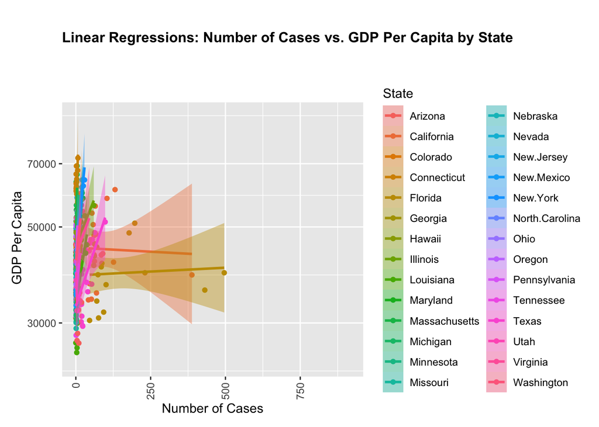

```r
combined_data <- bind_rows(state_data_frames, .id = "State")
text_size = 12
#GDP
ggplot(data = combined_data, aes(x = Filings, y = GDP, color = State, fill = State)) +
  geom_point() +
  scale_y_log10()  +
  geom_smooth(method = "lm", se = TRUE) +
  labs(title = "Linear Regressions: Number of Cases vs. GDP Per Capita by State",
         x = "Number of Cases",
         y = " GDP Per Capita") +
    theme(plot.margin = margin(t = 70, r = 10, b = 10, l = 10, unit = "pt"),
    axis.text.x = element_text(angle = 90, hjust=1, vjust = .5),
    plot.title = element_text(hjust = 0, vjust = 18, face = "bold", size = text_size)
  )
```

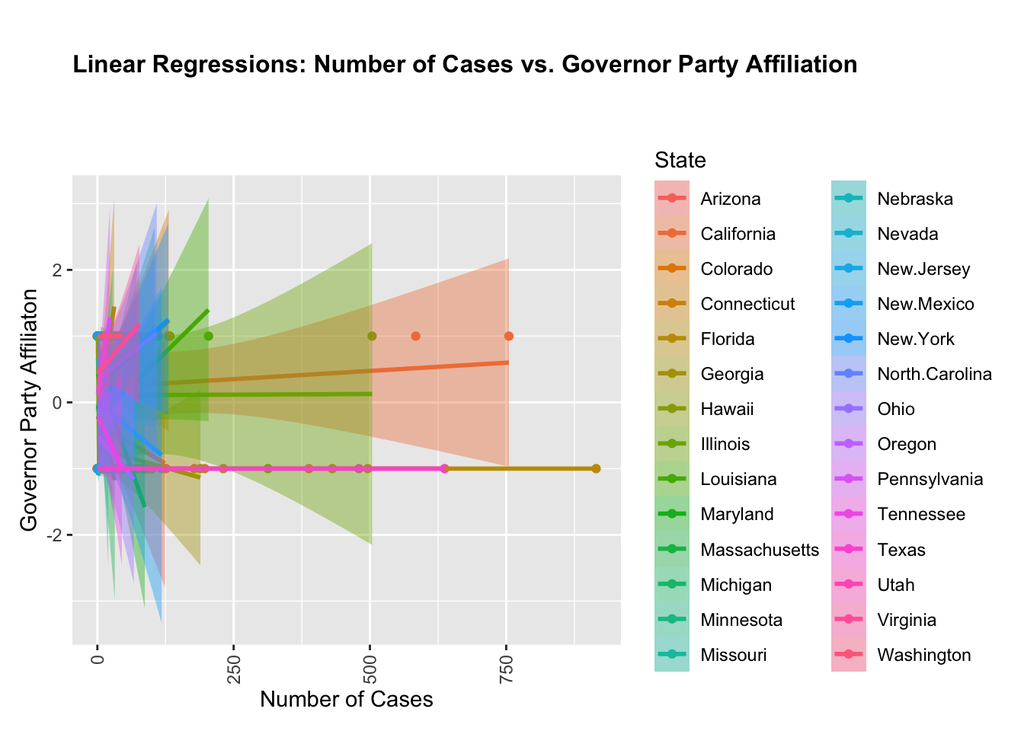

```r
#Gov
ggplot(data = combined_data, aes(x = Filings, y = Gov, color = State, fill = State)) +
  geom_point() +
  geom_smooth(method = "lm", se = TRUE) +
 labs(title = "Linear Regressions: Number of Cases vs. Governor Party Affiliation",
         x = "Number of Cases",
         y = "Governor Party Affiliaton") +
   theme(plot.margin = margin(t = 70, r = 10, b = 10, l = 10, unit = "pt"),
    axis.text.x = element_text(angle = 90, hjust=1, vjust = .5),
    plot.title = element_text(hjust = 0, vjust = 18, face = "bold", size = text_size)
  )
```

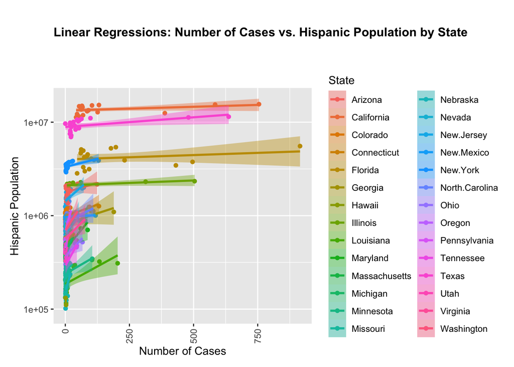

```r
#Hispop
ggplot(data = combined_data, aes(x = Filings, y = HispanicPopulation, color = State, fill = State)) +
  geom_point() +
  geom_smooth(method = "lm", se = TRUE) +
  scale_y_log10() +   # Logarithmic scale for y-axis+
  labs(title = "Linear Regressions: Number of Cases vs. Hispanic Population by State",
         x = "Number of Cases",
         y = "Hispanic Population") +
   theme(plot.margin = margin(t = 70, r = 10, b = 10, l = 10, unit = "pt"),
    axis.text.x = element_text(angle = 90, hjust=1, vjust = .5),
    plot.title = element_text(hjust = 0, vjust = 18, face = "bold", size = text_size)
  )
```

```r
#Mulitple regression sumary information for each state
regression_summaries <- list()

for(i in states) {
  state_data <- subset(combined_data, State == i)

  models <- lm(Filings ~ HispanicPopulation + GDP + Gov, data = state_data)

  regression_summaries[[i]] <- summary(models)
}
```

```r
#consolodate data for Texas
Texas_filings <- as.numeric(filings$Texas)
year <-  as.numeric(filings$State)
Texas_GDP <-  as.numeric(GDP$Texas)
Texas_Gov <-  as.numeric(Gov$Texas)
Texas_denied <- as.numeric(denied$Texas)
Texas_approve <- as.numeric(approve$Texas)
Texas_hispop <- as.numeric(gsub(",", "", hispop$Texas))

#data frame
Texas_data <- data.frame(Year = year, Filings = Texas_filings, HispanicPopulation = Texas_hispop, GDP = Texas_GDP, Gov = Texas_Gov, den = Texas_denied, app = Texas_approve)

#long data
long_data_Texas <- gather(Texas_data, key = "variable", value = "value", -Filings, -Year, -app, -den)

#Florida
Florida_filings <- as.numeric(filings$Florida)
year <- as.numeric(filings$State)
Florida_GDP <- as.numeric(GDP$Florida)
Florida_Gov <- as.numeric(Gov$Florida)
Florida_denied <- as.numeric(denied$Florida)
Florida_approve <- as.numeric(approve$Florida)

Florida_hispop <- as.numeric(gsub(",", "", hispop$Florida))

#data frame
Florida_data <- data.frame(Year = year, Filings = Florida_filings, HispanicPopulation = Florida_hispop, GDP = Florida_GDP, Gov = Florida_Gov, den = Florida_denied, app = Florida_approve)

#long data
long_data_Florida <- gather(Florida_data, key = "variable", value = "value", -Filings, -Year, -app, -den)

#California
California_filings <- as.numeric(filings$California)
year <-  as.numeric(filings$State)
California_GDP <-  as.numeric(GDP$California)
California_Gov <-  as.numeric(Gov$California)
California_denied <- as.numeric(denied$California)
California_approve <- as.numeric(approve$California)

California_hispop <- as.numeric(gsub(",", "", hispop$California))

#data frame
California_data <- data.frame(Year = year, Filings = California_filings, HispanicPopulation = California_hispop, GDP = California_GDP, Gov = California_Gov, den = California_denied, app = California_approve)

#long data
long_data_California <- gather(California_data, key = "variable", value = "value", -Filings, -Year, -app, -den)


#Florida
Florida_filings <- as.numeric(filings$Florida)
year <- as.numeric(filings$State)
Florida_GDP <- as.numeric(GDP$Florida)
Florida_Gov <- as.numeric(Gov$Florida)
Florida_denied <- as.numeric(denied$Florida)
Florida_approve <- as.numeric(approve$Florida)

Florida_hispop <- as.numeric(gsub(",", "", hispop$Florida))

#data frame
Florida_data <- data.frame(Year = year, Filings = Florida_filings, HispanicPopulation = Florida_hispop, GDP = Florida_GDP, Gov = Florida_Gov, den = Florida_denied, app = Florida_approve)

#long data
long_data_Florida <- gather(Florida_data, key = "variable", value = "value", -Filings, -Year, -app, -den)

#California
Louisiana_filings <- as.numeric(filings$Louisiana)
year <-  as.numeric(filings$State)
Louisiana_GDP <-  as.numeric(GDP$Louisiana)
Louisiana_Gov <-  as.numeric(Gov$Louisiana)
Louisiana_denied <- as.numeric(denied$Louisiana)
Louisiana_approve <- as.numeric(approve$Louisiana)
Louisiana_hispop <- as.numeric(gsub(",", "", hispop$Louisiana))

#data frame
Louisiana_data <- data.frame(Year = year, Filings = Louisiana_filings, HispanicPopulation = Louisiana_hispop, GDP = Louisiana_GDP, Gov = Louisiana_Gov, den = Louisiana_denied, app = Louisiana_approve)

#long data
long_data_Louisiana <- gather(Louisiana_data, key = "variable", value = "value", -Filings, -Year, -app, -den)
```

3. Result section

Given the extensive dataset at hand, I decided to perform regression analyses for four specific states: California, Florida, Texas, and Louisiana. The rationale for selecting these states primarily relates to their graphical representation, as they visually exhibit a possible connection between the variables.

Analyzing the regression results for Texas, the coefficient for the Hispanic population is -0.0000176. This implies a slight decrease in the number of asylum cases for each incremental increase in the Hispanic population, but this result is not statistically significant (p-value = 0.368). Similarly, the GDP coefficient is 0.0052397, indicating a minor increase in asylum cases for every unit rise in GDP per capita, but this, too, lacks statistical significance (p-value = 0.155). The absence of statistical significance means we cannot confidently rule out the possibility that these relationships occurred by random chance alone. Therefore, inferring causality from these coefficients would be premature. Further investigation should consider additional variables and the potential for omitted variable bias.

Moving to the regression analysis for Florida, the coefficient for the Hispanic population reveals -0.0004769, signifying a slight reduction in cases for each unit increase in the Hispanic population. Importantly, this result is statistically significant with a p-value of 0.0018210, indicating a robust relationship within the data. The GDP coefficient is 0.0647874, suggesting a positive correlation with the number of cases, and it also achieves statistical significance (p-value = 0.0019682). Nonetheless, despite their statistical significance, these coefficients should not be prematurely interpreted as causal without further investigation to account for potential confounding variables.

Lastly, in the context of the California regression, the coefficient for the Hispanic population is -0.0000512, pointing to an extremely small reduction in cases with each unit increase in the Hispanic population, but this result is not statistically significant (p-value = 0.2829558). The GDP coefficient, at 0.0088341, suggests a minor positive association with the number of cases; however, this result also fails to achieve statistical significance (p-value = 0.2519628). The coefficient for the governor variable is -35.3679313, yet its lack of statistical significance (p-value = 0.1139449) prevents us from confidently interpreting it as indicative of a causal relationship. In light of these results, it appears that within the California dataset, these variables do not exert a substantial or statistically significant influence on the number of asylum cases.

In summary, while the regression analyses provide insights into potential associations, it is crucial to exercise caution in inferring causality, especially in cases where statistical significance is lacking. Further exploration and consideration of additional variables are essential to gain a more comprehensive understanding of these relationships.

(I included a regression analysis for all states in my study, but I only discussed the results for those states for which I created graphs)

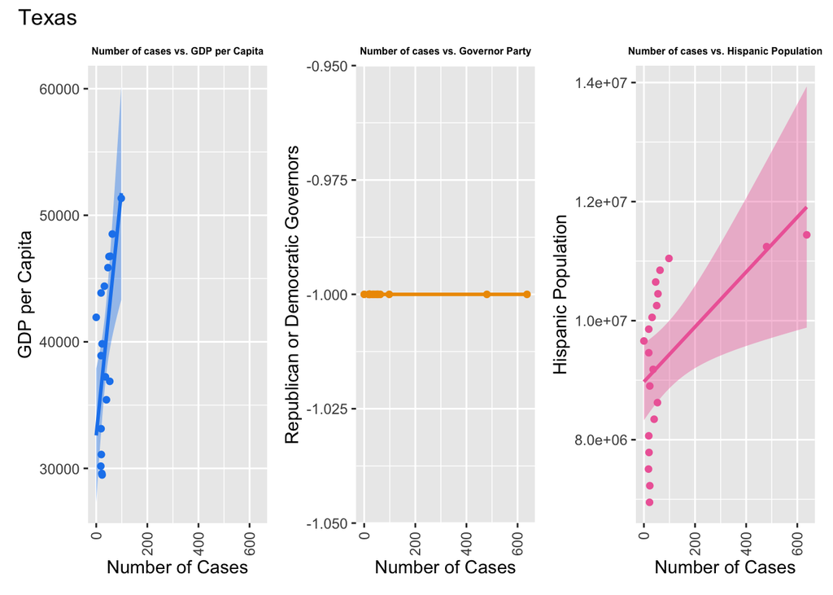

```r
# install.packages("patchwork")




text_size = 6

#Texas
######################################################################################################
plot1 <- ggplot(subset(long_data_Texas, variable == "GDP"), aes(x = Filings, y = value)) +
  geom_point(color = "dodgerblue2") +
  geom_smooth(method = "lm", se = TRUE, color = "dodgerblue2", fill = "dodgerblue2") +
  labs(title = "Number of cases vs. GDP per Capita",
         x = "Number of Cases",
         y = "GDP per Capita",
         color = "Legend") +
    theme(axis.text.x = element_text(angle = 90, vjust = 0.5, hjust=1),
          plot.title = element_text(hjust = 0.5, size = text_size, face = "bold"),
          legend.position = "bottom")


plot2 <- ggplot(subset(long_data_Texas, variable == "Gov"), aes(x = Filings, y = value)) +
  geom_point(color = "orange2") +
  geom_smooth(method = "lm", se = TRUE, color = "orange2", fill = "orange2") +
 labs(title = "Number of cases vs. Governor Party",
         x = "Number of Cases",
         y = "Republican or Democratic Governors",
         color = "Legend") +
    theme(axis.text.x = element_text(angle = 90, vjust = 0.5, hjust=1),
          plot.title = element_text(hjust = 0.5, size = text_size, face = "bold"),
          legend.position = "bottom")



plot3 <- ggplot(subset(long_data_Texas, variable == "HispanicPopulation"), aes(x = Filings, y = value)) +
  geom_point(color = "hotpink2") +
  geom_smooth(method = "lm", se = TRUE, color = "hotpink2", fill = "hotpink2") +
 labs(title = "Number of cases vs. Hispanic Population",
         x = "Number of Cases",
         y = "Hispanic Population",
         color = "Legend") +
    theme(axis.text.x = element_text(angle = 90, vjust = 0.5, hjust=1),
          plot.title = element_text(hjust = 0.5, size = text_size, face = "bold"),
          legend.position = "bottom")

#plots
combined_plot <- plot1 | plot2 | plot3

# Add an overarching title
combined_plot_with_title <- combined_plot +
    plot_annotation(title = "Texas")

combined_plot_with_title
```

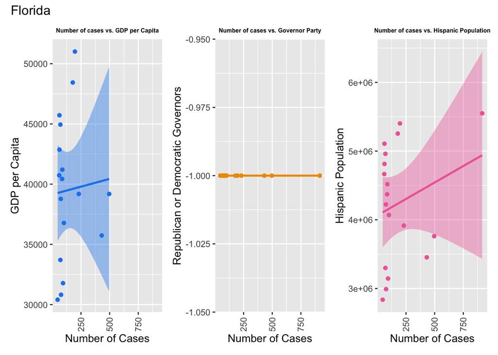

```r
ggsave("my_combined_plot_Texas.png", combined_plot_with_title, width = 12, height = 4)
#Florida
######################################################################################################


plot1 <- ggplot(subset(long_data_Florida, variable == "GDP"), aes(x = Filings, y = value)) +
  geom_point(color = "dodgerblue2") +
  geom_smooth(method = "lm", se = TRUE, color = "dodgerblue2", fill = "dodgerblue2") +
  labs(title = "Number of cases vs. GDP per Capita",
         x = "Number of Cases",
         y = "GDP per Capita",
         color = "Legend") +
    theme(axis.text.x = element_text(angle = 90, vjust = 0.5, hjust=1),
          plot.title = element_text(hjust = 0.5, size = text_size, face = "bold"),
          legend.position = "bottom")


plot2 <- ggplot(subset(long_data_Florida, variable == "Gov"), aes(x = Filings, y = value)) +
  geom_point(color = "orange2") +
  geom_smooth(method = "lm", se = TRUE, color = "orange2", fill = "orange2") +
 labs(title = "Number of cases vs. Governor Party",
         x = "Number of Cases",
         y = "Republican or Democratic Governors",
         color = "Legend") +
    theme(axis.text.x = element_text(angle = 90, vjust = 0.5, hjust=1),
          plot.title = element_text(hjust = 0.5, size = text_size, face = "bold"),
          legend.position = "bottom")



plot3 <- ggplot(subset(long_data_Florida, variable == "HispanicPopulation"), aes(x = Filings, y = value)) +
  geom_point(color = "hotpink2") +
  geom_smooth(method = "lm", se = TRUE, color = "hotpink2", fill = "hotpink2") +
 labs(title = "Number of cases vs. Hispanic Population",
         x = "Number of Cases",
         y = "Hispanic Population",
         color = "Legend") +
    theme(axis.text.x = element_text(angle = 90, vjust = 0.5, hjust=1),
          plot.title = element_text(hjust = 0.5, size = text_size, face = "bold"),
          legend.position = "bottom")


combined_plot <- plot1 | plot2 | plot3

# Add an overarching title
combined_plot_with_title <- combined_plot +
    plot_annotation(title = "Florida")

combined_plot_with_title
```

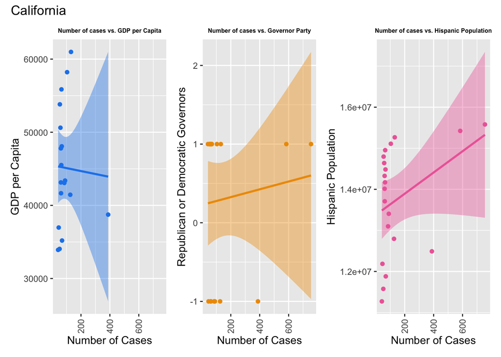

```r
ggsave("my_combined_plot_Florida.png", combined_plot_with_title, width = 12, height = 4)
#California
######################################################################################################

plot1 <- ggplot(subset(long_data_California, variable == "GDP"), aes(x = Filings, y = value)) +
  geom_point(color = "dodgerblue2") +
  geom_smooth(method = "lm", se = TRUE, color = "dodgerblue2", fill = "dodgerblue2") +
  labs(title = "Number of cases vs. GDP per Capita",
         x = "Number of Cases",
         y = "GDP per Capita",
         color = "Legend") +
    theme(axis.text.x = element_text(angle = 90, vjust = 0.5, hjust=1),
          plot.title = element_text(hjust = 0.5, size = text_size, face = "bold"),
          legend.position = "bottom")


plot2 <- ggplot(subset(long_data_California, variable == "Gov"), aes(x = Filings, y = value)) +
  geom_point(color = "orange2") +
  geom_smooth(method = "lm", se = TRUE, color = "orange2", fill = "orange2") +
 labs(title = "Number of cases vs. Governor Party",
         x = "Number of Cases",
         y = "Republican or Democratic Governors",
         color = "Legend") +
    theme(axis.text.x = element_text(angle = 90, vjust = 0.5, hjust=1),
          plot.title = element_text(hjust = 0.5, size = text_size, face = "bold"),
          legend.position = "bottom")



plot3 <- ggplot(subset(long_data_California, variable == "HispanicPopulation"), aes(x = Filings, y = value)) +
  geom_point(color = "hotpink2") +
  geom_smooth(method = "lm", se = TRUE, color = "hotpink2", fill = "hotpink2") +
 labs(title = "Number of cases vs. Hispanic Population",
         x = "Number of Cases",
         y = "Hispanic Population",
         color = "Legend") +
    theme(axis.text.x = element_text(angle = 90, vjust = 0.5, hjust=1),
          plot.title = element_text(hjust = 0.5, size = text_size, face = "bold"),
          legend.position = "bottom")


combined_plot <- plot1 | plot2 | plot3

# Add an overarching title
combined_plot_with_title <- combined_plot +
    plot_annotation(title = "California")

combined_plot_with_title
```

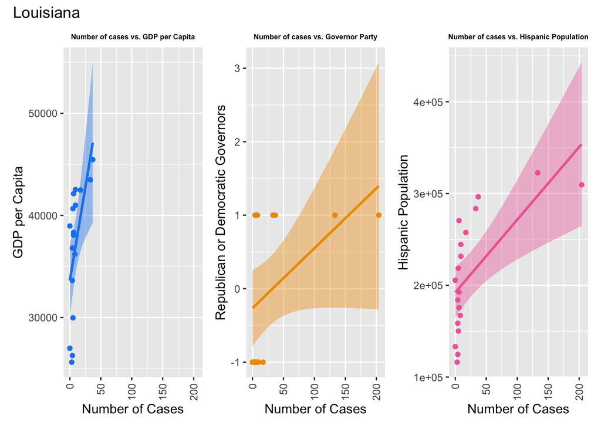

```r
ggsave("my_combined_plot_California.png", combined_plot_with_title, width = 12, height = 4)
#Louisiana
######################################################################################################

plot1 <- ggplot(subset(long_data_Louisiana, variable == "GDP"), aes(x = Filings, y = value)) +
  geom_point(color = "dodgerblue2") +
  geom_smooth(method = "lm", se = TRUE, color = "dodgerblue2", fill = "dodgerblue2") +
  labs(title = "Number of cases vs. GDP per Capita",
         x = "Number of Cases",
         y = "GDP per Capita",
         color = "Legend") +
    theme(axis.text.x = element_text(angle = 90, vjust = 0.5, hjust=1),
          plot.title = element_text(hjust = 0.5, size = text_size, face = "bold"),
          legend.position = "bottom")


plot2 <- ggplot(subset(long_data_Louisiana, variable == "Gov"), aes(x = Filings, y = value)) +
  geom_point(color = "orange2") +
  geom_smooth(method = "lm", se = TRUE, color = "orange2", fill = "orange2") +
 labs(title = "Number of cases vs. Governor Party",
         x = "Number of Cases",
         y = "Republican or Democratic Governors",
         color = "Legend") +
    theme(axis.text.x = element_text(angle = 90, vjust = 0.5, hjust=1),
          plot.title = element_text(hjust = 0.5, size = text_size, face = "bold"),
          legend.position = "bottom")



plot3 <- ggplot(subset(long_data_Louisiana, variable == "HispanicPopulation"), aes(x = Filings, y = value)) +
  geom_point(color = "hotpink2") +
  geom_smooth(method = "lm", se = TRUE, color = "hotpink2", fill = "hotpink2") +
 labs(title = "Number of cases vs. Hispanic Population",
         x = "Number of Cases",
         y = "Hispanic Population",
         color = "Legend") +
    theme(axis.text.x = element_text(angle = 90, vjust = 0.5, hjust=1),
          plot.title = element_text(hjust = 0.5, size = text_size, face = "bold"),
          legend.position = "bottom")


combined_plot <- plot1 | plot2 | plot3

# Add an overarching title
combined_plot_with_title <- combined_plot +
    plot_annotation(title = "Louisiana")

combined_plot_with_title
```

```r
ggsave("my_combined_plot_Louisiana.png", combined_plot_with_title, width = 12, height = 4)
#Pull data from Multiple Regression done before for Texas


kable((regression_summaries[["Texas"]]$coefficients))
```

|  | Estimate | Std. Error | t value | Pr(>\|t\|) |
| --- | --- | --- | --- | --- |
| (Intercept) | -10.3807383 | 45.602191 | -0.2276368 | 0.8230023 |
| HispanicPopulation | -0.0000176 | 0.000019 | -0.9266029 | 0.3688023 |
| GDP | 0.0052397 | 0.003502 | 1.4961870 | 0.1553474 |

```r
# kable((regression_summaries[["Texas"]]$r.quared))
```

```r
#Pull data from Multiple Regression done before for California

kable((regression_summaries[["California"]]$coefficients))
```

|  | Estimate | Std. Error | t value | Pr(>\|t\|) |
| --- | --- | --- | --- | --- |
| (Intercept) | 393.2756930 | 327.9534073 | 1.199182 | 0.2503607 |
| HispanicPopulation | -0.0000512 | 0.0000458 | -1.116618 | 0.2829558 |
| GDP | 0.0088341 | 0.0073930 | 1.194936 | 0.2519628 |
| Gov | -35.3679313 | 20.9774931 | -1.685994 | 0.1139449 |

```r
#Pull data from Multiple Regression done before for Florida

kable((regression_summaries[["Florida"]]$coefficients))
```

|  | Estimate | Std. Error | t value | Pr(>\|t\|) |
| --- | --- | --- | --- | --- |
| (Intercept) | -431.7370604 | 213.9653455 | -2.017790 | 0.0632018 |
| HispanicPopulation | -0.0004769 | 0.0001244 | -3.834901 | 0.0018210 |
| GDP | 0.0647874 | 0.0170695 | 3.795515 | 0.0019682 |

```r
#Pull data from Multiple Regression done before for Louisiana
kable((regression_summaries[["Louisiana"]]$coefficients))
```

|  | Estimate | Std. Error | t value | Pr(>\|t\|) |
| --- | --- | --- | --- | --- |
| (Intercept) | 3.5042779 | 13.9949293 | 0.2503963 | 0.8061946 |
| HispanicPopulation | 0.0002495 | 0.0000879 | 2.8390126 | 0.0139476 |
| GDP | -0.0011870 | 0.0007830 | -1.5160332 | 0.1534442 |
| Gov | 2.7548629 | 1.7091280 | 1.6118529 | 0.1309956 |

```r
#Print Summary for all of the States' Multiple Regressions
for (State in names(regression_summaries)) {
  cat('\n\n')
  cat("State: ", State, "\n\n")
  coefficients_table <- regression_summaries[[State]]$coefficients
  print(kable(as.data.frame(coefficients_table), format = "simple", caption = "Coefficients"))
  summary_stats <- regression_summaries[[State]]
  additional_stats_df <- data.frame(
    Statistic = c("R-squared", "Adjusted R-squared", "F-statistic", "Degrees of Freedom"),
    Value = c(summary_stats$r.squared, summary_stats$adj.r.squared, summary_stats$fstatistic[1],summary_stats$df[2] ))
  print(kable(additional_stats_df, format = "simple", caption = "Additional Statistics"))
  cat('\n\n')
}
```

State: California

Coefficients

|  | Estimate | Std. Error | t value | Pr(>\|t\|) |
| --- | --- | --- | --- | --- |
| (Intercept) | 393.2756930 | 327.9534073 | 1.199182 | 0.2503607 |
| HispanicPopulation | -0.0000512 | 0.0000458 | -1.116618 | 0.2829558 |
| GDP | 0.0088341 | 0.0073930 | 1.194936 | 0.2519628 |
| Gov | -35.3679313 | 20.9774931 | -1.685994 | 0.1139449 |

Additional Statistics

| Statistic | Value |
| --- | --- |
| R-squared | 0.1960809 |
| Adjusted R-squared | 0.0238125 |
| F-statistic | 1.1382292 |
| Degrees of Freedom | 14.0000000 |

State: New.York

Coefficients

|  | Estimate | Std. Error | t value | Pr(>\|t\|) |
| --- | --- | --- | --- | --- |
| (Intercept) | 48.3932838 | 27.8449334 | 1.737956 | 0.1041538 |
| HispanicPopulation | -0.0000560 | 0.0000151 | -3.722322 | 0.0022746 |
| GDP | 0.0030948 | 0.0005057 | 6.119312 | 0.0000265 |
| Gov | -5.3345866 | 1.1899355 | -4.483089 | 0.0005156 |

Additional Statistics

| Statistic | Value |
| --- | --- |
| R-squared | 0.9011083 |
| Adjusted R-squared | 0.8799173 |
| F-statistic | 42.5230246 |
| Degrees of Freedom | 14.0000000 |

State: Florida

Coefficients

|  | Estimate | Std. Error | t value | Pr(>\|t\|) |
| --- | --- | --- | --- | --- |
| (Intercept) | -431.7370604 | 213.9653455 | -2.017790 | 0.0632018 |
| HispanicPopulation | -0.0004769 | 0.0001244 | -3.834901 | 0.0018210 |
| GDP | 0.0647874 | 0.0170695 | 3.795515 | 0.0019682 |

Additional Statistics

| Statistic | Value |
| --- | --- |
| R-squared | 0.5139013 |
| Adjusted R-squared | 0.4444587 |
| F-statistic | 7.4003691 |
| Degrees of Freedom | 14.0000000 |

State: Texas

Coefficients

|  | Estimate | Std. Error | t value | Pr(>\|t\|) |
| --- | --- | --- | --- | --- |
| (Intercept) | -10.3807383 | 45.602191 | -0.2276368 | 0.8230023 |
| HispanicPopulation | -0.0000176 | 0.000019 | -0.9266029 | 0.3688023 |
| GDP | 0.0052397 | 0.003502 | 1.4961870 | 0.1553474 |

Additional Statistics

| Statistic | Value |
| --- | --- |
| R-squared | 0.4325276 |
| Adjusted R-squared | 0.3568646 |
| F-statistic | 5.7165017 |
| Degrees of Freedom | 15.0000000 |

State: New.Jersey

Coefficients

|  | Estimate | Std. Error | t value | Pr(>\|t\|) |
| --- | --- | --- | --- | --- |
| (Intercept) | -26.5154426 | 7.5224216 | -3.524855 | 0.0033649 |
| HispanicPopulation | -0.0000701 | 0.0000266 | -2.635624 | 0.0195706 |
| GDP | 0.0027893 | 0.0008301 | 3.360347 | 0.0046669 |
| Gov | -1.2737925 | 1.1042893 | -1.153495 | 0.2680205 |

Additional Statistics

| Statistic | Value |
| --- | --- |
| R-squared | 0.7087799 |
| Adjusted R-squared | 0.6463756 |
| F-statistic | 11.3578702 |
| Degrees of Freedom | 14.0000000 |

State: Massachusetts

Coefficients

|  | Estimate | Std. Error | t value | Pr(>\|t\|) |
| --- | --- | --- | --- | --- |
| (Intercept) | -0.7948492 | 2.6736326 | -0.2972919 | 0.7748723 |
| HispanicPopulation | 0.0000066 | 0.0000209 | 0.3149888 | 0.7619521 |
| GDP | -0.0000246 | 0.0002813 | -0.0874663 | 0.9327504 |
| Gov | -0.0927822 | 0.3349068 | -0.2770388 | 0.7897528 |

Additional Statistics

| Statistic | Value |
| --- | --- |
| R-squared | 0.2901312 |
| Adjusted R-squared | -0.0140983 |
| F-statistic | 0.9536591 |
| Degrees of Freedom | 7.0000000 |

State: Virginia

Coefficients

|  | Estimate | Std. Error | t value | Pr(>\|t\|) |
| --- | --- | --- | --- | --- |
| (Intercept) | -97.6929235 | 51.3903043 | -1.900999 | 0.0797008 |
| HispanicPopulation | -0.0001777 | 0.0001143 | -1.554774 | 0.1440001 |
| GDP | 0.0047011 | 0.0026368 | 1.782868 | 0.0979610 |
| Gov | 2.9040843 | 3.1717724 | 0.915603 | 0.3765468 |

Additional Statistics

| Statistic | Value |
| --- | --- |
| R-squared | 0.3066688 |
| Adjusted R-squared | 0.1466693 |
| F-statistic | 1.9166862 |
| Degrees of Freedom | 13.0000000 |

State: Illinois

Coefficients

|  | Estimate | Std. Error | t value | Pr(>\|t\|) |
| --- | --- | --- | --- | --- |
| (Intercept) | 86.9924073 | 71.6061758 | 1.2148730 | 0.3113107 |
| HispanicPopulation | -0.0002948 | 0.0000975 | -3.0251588 | 0.0565274 |
| GDP | 0.0113549 | 0.0033436 | 3.3960320 | 0.0425854 |
| Gov | -3.0339252 | 5.0915699 | -0.5958722 | 0.5932237 |

Additional Statistics

| Statistic | Value |
| --- | --- |
| R-squared | 0.9142808 |
| Adjusted R-squared | 0.8285616 |
| F-statistic | 10.6659981 |
| Degrees of Freedom | 3.0000000 |

State: Maryland

Coefficients

|  | Estimate | Std. Error | t value | Pr(>\|t\|) |
| --- | --- | --- | --- | --- |
| (Intercept) | 19.0179516 | 25.6363188 | 0.7418363 | 0.4724568 |
| HispanicPopulation | 0.0000806 | 0.0000493 | 1.6335125 | 0.1283054 |
| GDP | -0.0009977 | 0.0009764 | -1.0218030 | 0.3270327 |
| Gov | -3.4876367 | 1.0917914 | -3.1944166 | 0.0077120 |

Additional Statistics

| Statistic | Value |
| --- | --- |
| R-squared | 0.7080779 |
| Adjusted R-squared | 0.6350974 |
| F-statistic | 9.7022874 |
| Degrees of Freedom | 12.0000000 |

State: Washington

Coefficients

|  | Estimate | Std. Error | t value | Pr(>\|t\|) |
| --- | --- | --- | --- | --- |
| (Intercept) | -7.8080302 | 7.3848263 | -1.0573072 | 0.3082750 |
| HispanicPopulation | -0.0000249 | 0.0000312 | -0.7979923 | 0.4382019 |
| GDP | 0.0006899 | 0.0006341 | 1.0880150 | 0.2949649 |

Additional Statistics

| Statistic | Value |
| --- | --- |
| R-squared | 0.1695707 |
| Adjusted R-squared | 0.0509379 |
| F-statistic | 1.4293747 |
| Degrees of Freedom | 14.0000000 |

State: Georgia

Coefficients

|  | Estimate | Std. Error | t value | Pr(>\|t\|) |
| --- | --- | --- | --- | --- |
| (Intercept) | -39.1907528 | 8.9120680 | -4.397493 | 0.0013403 |
| HispanicPopulation | -0.0000500 | 0.0000176 | -2.843682 | 0.0174380 |
| GDP | 0.0022922 | 0.0005324 | 4.305670 | 0.0015476 |
| Gov | -2.1065024 | 1.9092752 | -1.103300 | 0.2957393 |

Additional Statistics

| Statistic | Value |
| --- | --- |
| R-squared | 0.7493247 |
| Adjusted R-squared | 0.6741221 |
| F-statistic | 9.9640792 |
| Degrees of Freedom | 10.0000000 |

State: Pennsylvania

Coefficients

|  | Estimate | Std. Error | t value | Pr(>\|t\|) |
| --- | --- | --- | --- | --- |
| (Intercept) | -17.3118402 | 5.5778883 | -3.1036549 | 0.0100385 |
| HispanicPopulation | -0.0000446 | 0.0000151 | -2.9489035 | 0.0132353 |
| GDP | 0.0011982 | 0.0003805 | 3.1495082 | 0.0092503 |
| Gov | 0.1215296 | 0.2718340 | 0.4470728 | 0.6634973 |

Additional Statistics

| Statistic | Value |
| --- | --- |
| R-squared | 0.5898908 |
| Adjusted R-squared | 0.4780428 |
| F-statistic | 5.2740414 |
| Degrees of Freedom | 11.0000000 |

State: Tennessee

Coefficients

|  | Estimate | Std. Error | t value | Pr(>\|t\|) |
| --- | --- | --- | --- | --- |
| (Intercept) | -29.8131355 | 41.6703386 | -0.7154522 | 0.4974932 |
| HispanicPopulation | -0.0000701 | 0.0001386 | -0.5058329 | 0.6285104 |
| GDP | 0.0015056 | 0.0022403 | 0.6720555 | 0.5231032 |
| Gov | 0.9769318 | 1.6321276 | 0.5985634 | 0.5683190 |

Additional Statistics

| Statistic | Value |
| --- | --- |
| R-squared | 0.2235622 |
| Adjusted R-squared | -0.1091968 |
| F-statistic | 0.6718442 |
| Degrees of Freedom | 7.0000000 |

State: Louisiana

Coefficients

|  | Estimate | Std. Error | t value | Pr(>\|t\|) |
| --- | --- | --- | --- | --- |
| (Intercept) | 3.5042779 | 13.9949293 | 0.2503963 | 0.8061946 |
| HispanicPopulation | 0.0002495 | 0.0000879 | 2.8390126 | 0.0139476 |
| GDP | -0.0011870 | 0.0007830 | -1.5160332 | 0.1534442 |
| Gov | 2.7548629 | 1.7091280 | 1.6118529 | 0.1309956 |

Additional Statistics

| Statistic | Value |
| --- | --- |
| R-squared | 0.6600312 |
| Adjusted R-squared | 0.5815768 |
| F-statistic | 8.4129334 |
| Degrees of Freedom | 13.0000000 |

State: Arizona

Coefficients

|  | Estimate | Std. Error | t value | Pr(>\|t\|) |
| --- | --- | --- | --- | --- |
| (Intercept) | 3.6337515 | 9.5940472 | 0.3787506 | 0.7105549 |
| HispanicPopulation | 0.0000105 | 0.0000150 | 0.7035226 | 0.4932653 |
| GDP | -0.0003948 | 0.0006974 | -0.5660265 | 0.5803360 |
| Gov | 2.0377704 | 1.4286351 | 1.4263757 | 0.1756783 |

Additional Statistics

| Statistic | Value |
| --- | --- |
| R-squared | 0.1287914 |
| Adjusted R-squared | -0.0578961 |
| F-statistic | 0.6898769 |
| Degrees of Freedom | 14.0000000 |

State: Ohio

Coefficients

|  | Estimate | Std. Error | t value | Pr(>\|t\|) |
| --- | --- | --- | --- | --- |
| (Intercept) | -23.7165511 | 16.7408402 | -1.4166882 | 0.1902441 |
| HispanicPopulation | -0.0000473 | 0.0000936 | -0.5057972 | 0.6251544 |
| GDP | 0.0011503 | 0.0013060 | 0.8807326 | 0.4013695 |
| Gov | 0.1517198 | 0.8282287 | 0.1831859 | 0.8587125 |

Additional Statistics

| Statistic | Value |
| --- | --- |
| R-squared | 0.5873542 |
| Adjusted R-squared | 0.4498056 |
| F-statistic | 4.2701579 |
| Degrees of Freedom | 9.0000000 |

State: Nebraska

Coefficients

|  | Estimate | Std. Error | t value | Pr(>\|t\|) |
| --- | --- | --- | --- | --- |
| (Intercept) | 6.3805950 | 6.9497561 | 0.9181034 | 0.3766492 |
| HispanicPopulation | 0.0000734 | 0.0001045 | 0.7024741 | 0.4957850 |
| GDP | -0.0003641 | 0.0005536 | -0.6577139 | 0.5231387 |

Additional Statistics

| Statistic | Value |
| --- | --- |
| R-squared | 0.0421983 |
| Adjusted R-squared | -0.1174353 |
| F-statistic | 0.2643446 |
| Degrees of Freedom | 12.0000000 |

State: Colorado

Coefficients

|  | Estimate | Std. Error | t value | Pr(>\|t\|) |
| --- | --- | --- | --- | --- |
| (Intercept) | -15.6616540 | 16.8456428 | -0.9297154 | 0.3724718 |
| HispanicPopulation | -0.0000190 | 0.0000367 | -0.5183650 | 0.6144706 |
| GDP | 0.0008769 | 0.0005530 | 1.5857486 | 0.1411034 |
| Gov | -0.2944931 | 2.2750769 | -0.1294432 | 0.8993436 |

Additional Statistics

| Statistic | Value |
| --- | --- |
| R-squared | 0.5223421 |
| Adjusted R-squared | 0.3920717 |
| F-statistic | 4.0096775 |
| Degrees of Freedom | 11.0000000 |

State: North.Carolina

Coefficients

|  | Estimate | Std. Error | t value | Pr(>\|t\|) |
| --- | --- | --- | --- | --- |
| (Intercept) | -16.6140511 | 9.2132338 | -1.8032812 | 0.1090049 |
| HispanicPopulation | -0.0000056 | 0.0000146 | -0.3844731 | 0.7106464 |
| GDP | 0.0006287 | 0.0005131 | 1.2253333 | 0.2552982 |
| Gov | 0.0946935 | 0.7361567 | 0.1286323 | 0.9008237 |

Additional Statistics

| Statistic | Value |
| --- | --- |
| R-squared | 0.5344758 |
| Adjusted R-squared | 0.3599043 |
| F-statistic | 3.0616430 |
| Degrees of Freedom | 8.0000000 |

State: Minnesota

Coefficients

|  | Estimate | Std. Error | t value | Pr(>\|t\|) |
| --- | --- | --- | --- | --- |
| (Intercept) | 2.5282590 | 11.4831314 | 0.2201716 | 0.8312521 |
| HispanicPopulation | 0.0000079 | 0.0000655 | 0.1198993 | 0.9075193 |
| GDP | -0.0000144 | 0.0005309 | -0.0270921 | 0.9790499 |
| Gov | 1.8507034 | 1.3352680 | 1.3860165 | 0.2031494 |

Additional Statistics

| Statistic | Value |
| --- | --- |
| R-squared | 0.6460029 |
| Adjusted R-squared | 0.5132539 |
| F-statistic | 4.8663509 |
| Degrees of Freedom | 8.0000000 |

State: Nevada

Coefficients

|  | Estimate | Std. Error | t value | Pr(>\|t\|) |
| --- | --- | --- | --- | --- |
| (Intercept) | -10.5307418 | 5.826717 | -1.807320 | 0.0908075 |
| HispanicPopulation | -0.0000143 | 0.000009 | -1.583370 | 0.1341896 |
| GDP | 0.0006057 | 0.000262 | 2.311708 | 0.0354132 |

Additional Statistics

| Statistic | Value |
| --- | --- |
| R-squared | 0.2900782 |
| Adjusted R-squared | 0.1954220 |
| F-statistic | 3.0645441 |
| Degrees of Freedom | 15.0000000 |

State: Missouri

Coefficients

|  | Estimate | Std. Error | t value | Pr(>\|t\|) |
| --- | --- | --- | --- | --- |
| (Intercept) | -18.5844986 | 20.6988229 | -0.8978529 | 0.3926494 |
| HispanicPopulation | -0.0001255 | 0.0001762 | -0.7118959 | 0.4945678 |
| GDP | 0.0012646 | 0.0015360 | 0.8232721 | 0.4316265 |
| Gov | 0.2755930 | 0.7171580 | 0.3842849 | 0.7096894 |

Additional Statistics

| Statistic | Value |
| --- | --- |
| R-squared | 0.2966602 |
| Adjusted R-squared | 0.0622136 |
| F-statistic | 1.2653638 |
| Degrees of Freedom | 9.0000000 |

State: Connecticut

Coefficients

|  | Estimate | Std. Error | t value | Pr(>\|t\|) |
| --- | --- | --- | --- | --- |
| (Intercept) | -2.4355310 | 4.8795416 | -0.4991311 | 0.6284841 |
| HispanicPopulation | 0.0000032 | 0.0000430 | 0.0746399 | 0.9419732 |
| GDP | 0.0000535 | 0.0003354 | 0.1593884 | 0.8765361 |
| Gov | 0.5444349 | 1.0492316 | 0.5188891 | 0.6151261 |

Additional Statistics

| Statistic | Value |
| --- | --- |
| R-squared | 0.3879306 |
| Adjusted R-squared | 0.2043098 |
| F-statistic | 2.1126725 |
| Degrees of Freedom | 10.0000000 |

State: Oregon

Coefficients

|  | Estimate | Std. Error | t value | Pr(>\|t\|) |
| --- | --- | --- | --- | --- |
| (Intercept) | 2.0073382 | 1.4324045 | 1.401377 | 0.1986825 |
| HispanicPopulation | 0.0000149 | 0.0000105 | 1.415452 | 0.1946650 |
| GDP | -0.0001873 | 0.0001245 | -1.504860 | 0.1707751 |

Additional Statistics

| Statistic | Value |
| --- | --- |
| R-squared | 0.2212012 |
| Adjusted R-squared | 0.0265015 |
| F-statistic | 1.1361149 |
| Degrees of Freedom | 8.0000000 |

State: Michigan

Coefficients

|  | Estimate | Std. Error | t value | Pr(>\|t\|) |
| --- | --- | --- | --- | --- |
| (Intercept) | -5.9138652 | 3.2073497 | -1.843848 | 0.1147645 |
| HispanicPopulation | -0.0001095 | 0.0000460 | -2.377920 | 0.0549238 |
| GDP | 0.0014911 | 0.0005977 | 2.494474 | 0.0468775 |
| Gov | 0.3224002 | 0.3023651 | 1.066261 | 0.3273191 |

Additional Statistics

| Statistic | Value |
| --- | --- |
| R-squared | 0.5649804 |
| Adjusted R-squared | 0.3474706 |
| F-statistic | 2.5974940 |
| Degrees of Freedom | 6.0000000 |

State: Utah

Coefficients

|  | Estimate | Std. Error | t value | Pr(>\|t\|) |
| --- | --- | --- | --- | --- |
| (Intercept) | 6.0295199 | 4.7499988 | 1.2693729 | 0.2938373 |
| HispanicPopulation | -0.0000035 | 0.0000310 | -0.1124330 | 0.9175812 |
| GDP | -0.0000742 | 0.0003196 | -0.2322717 | 0.8312703 |

Additional Statistics

| Statistic | Value |
| --- | --- |
| R-squared | 0.2119902 |
| Adjusted R-squared | -0.3133497 |
| F-statistic | 0.4035296 |
| Degrees of Freedom | 3.0000000 |

State: Hawaii

Coefficients

|  | Estimate | Std. Error | t value | Pr(>\|t\|) |
| --- | --- | --- | --- | --- |
| (Intercept) | 13.6674683 | NaN | NaN | NaN |
| HispanicPopulation | -0.0000962 | NaN | NaN | NaN |

Additional Statistics

| Statistic | Value |
| --- | --- |
| R-squared | 1 |
| Adjusted R-squared | NaN |
| F-statistic | NaN |
| Degrees of Freedom | 0 |

State: New.Mexico

Coefficients

|  | Estimate | Std. Error | t value | Pr(>\|t\|) |
| --- | --- | --- | --- | --- |
| (Intercept) | -46.7790756 | 59.2104330 | -0.7900479 | 0.4871901 |
| HispanicPopulation | 0.0000434 | 0.0000784 | 0.5530542 | 0.6187691 |
| GDP | 0.0001922 | 0.0005149 | 0.3732780 | 0.7337576 |
| Gov | 0.7906499 | 0.6864894 | 1.1517293 | 0.3328899 |

Additional Statistics

| Statistic | Value |
| --- | --- |
| R-squared | 0.659503 |
| Adjusted R-squared | 0.319006 |
| F-statistic | 1.936883 |
| Degrees of Freedom | 3.000000 |

4. Conclusion

The primary aim of this project was to examine the patterns in Nicaraguan asylum requests and determinations in the United States, with a specific focus on the potential influence of various state-level factors. My hypothesis suggested that the political affiliation of a state’s governor, the proportion of its Hispanic population, and the state’s GDP per capita would have a notable impact on these patterns, particularly after 2018.My regression analyses, which I conducted for selected states (California, Florida, Texas, and Louisiana), revealed a multifaceted and intricate scenario. For instance, in Florida, I identified a statistically significant correlation between the number of asylum cases and both the Hispanic population and GDP. However, in other states like Texas and California, the findings did not reach statistical significance, emphasizing the variation among different regions.

It is important to acknowledge the limitations inherent in this analysis. One major constraint is the reliance on historical data up to 2020, which does not account for recent political or economic developments that could influence asylum patterns. Additionally, the potential presence of confounding factors like legal representation access, or US immigration policies– which were not considered in the study but capable of affecting the results – should not be disregarded. Another limitation relates to my assumption of linear growth in the Hispanic population between census years. This assumption may not accurately mirror real-world demographic shifts, potentially introducing bias into the analysis. Furthermore, the choice to concentrate on asylum applications rather than approved or denied outcomes was based on data availability and reliability but may not fully capture the subtleties of immigration trends.

If additional time and resources were at my disposal, several enhancements could be implemented. Expanding the dataset to encompass more recent years would furnish a more up-to-date understanding of the patterns. Integrating supplementary variables, such as state-specific immigration policies or international political events, could offer a more holistic perspective. Qualitative research, including interviews with Nicaraguan migrants, could yield deeper insights into individual decision-making processes.

Ultimately, employing advanced statistical methods or machine learning techniques could potentially unveil more intricate relationships between the variables and asylum patterns. Collaborating with experts in immigration law, political science, and sociology could further enrich the analysis, providing a multidisciplinary view of this significant issue.

In conclusion, while this study does shed light on certain aspects of Nicaraguan asylum patterns in the United States, it also underscores the complexity of immigration trends and the ongoing necessity for research in this domain.